# Project 1: Bioinformatics of Gene Expression

Merrimack College DSE6630: Healthcare & Life Sciences Analytics

Katherine S. Geist, PhD

21 April 2024

# Background to the Project

## Overview

At the end of Assignment 1, you hopefully concluded that the SVM was performing better than the Random Forest algorithm, at least OOB. But the biggest problem we saw with both algorithms is sign of **overfitting**: when the testing error was higher than the training error (i.e., testing accuracy < training accuracy). Well, thankfully, we can address this with **cross-validation** and **tuning the hyperparameters**.

### Overfitting

When we optimize the model for the training data, our model will score very well on the training set. We expect this to be true (if it doesn’t, then training failed!). However, there may be times when the model in turn is not **generalizable**, meaning that it does not perform nearly as well on the test data set. When a model performs highly on the training set but poorly on the test set, this is known as **overfitting**. We have created a model that knows the training set very well but cannot be applied to new problems. Many textbooks use this analogy of overfitting, and I think it works very well: > We all knew a student in school who could memorize information, like answers to a quiz, but failed to apply those concepts in the real-world. That student’s mind was overfitted!

Therefore, an overfit model can look great on the training set but will be useless on other data because it is not generalizable. As mentioned above, we do have two keys ways of helping with this, though.

### Hyperparameter Tuning

What is a **hyperparameter**? Model parameters are those that are learned during training, e.g., the slope and intercept in a linear regression. Hyperparameters are external and not learned, and therefore must be set (or generated by default) by the data scientist before training. In the case of a random forest, hyperparameters include the the number of features considered by each tree when splitting a node for random forest or the kernel in SVM. Since the best hyperparameters are not something we can choose *a priori*, this is why we **tune the hyperparameters** as we train the model. This is done using trial-and-error, although there are some guidelines can often keep in mind to help ensure that we our models are on a good learning path.

As we (or the package we are using) performs the tuning, we are performing many iterations of the entire cross-validation process, whether that is $k$-fold or another CV method. We then compare all models, select the best one based on a performance metric (typically RMSE for regression or accuracy for classification), and train it on the full training set. Once we have our best model, we will then evaluate it on the testing set. Thus, even though you may not necessarily see all of the iterations involved, be aware of how extensive this process actually is!

## Objectives

We will spend our class session this week discussing overfitting, cross-validation, and hyperparameter tuning in greater detail. From there, I give you a demo how to tune the Random Forest we fit last week to the VST expression data for the bumblebee chill-coma experiment. **Your objective** will be to apply all the same methods to the SVM and compare and contrast your findings. Specifically, we will compare and contrast **nested cross-validation** versus **$k$-fold cross-validation** to see how well, if at all, we are able to overcome the **P >> n** problem we briefly introduced last week.

### Your Tasks:

#### 1. Answer questions scattered throughout the Random Forest CV and Tuning Sections to ensure your understanding (you may copy these answers, without code, to your project document.)

#### 2. Your own novel analysis! Choose from:

##### [Easier] Perform $k$-fold & nested CV, as well as hyperparameter tuning, on SVM a different VST (from the 30-minute experiment only)

##### [Harder] Ready to do go farther? Try performing $k$-fold & nested CV, as well as hyperparameter tuning, on SVM.

## Functions to make your life easier:

#### 1. `doSplits()`

Prepare the datasets, depending on algorithm, quickly and easily. This could also facilitate automated testing of filtering cutoffs or split-ratios by algorithm.

#### 2. `findOverlappingGenes()`

Function that compares the `DESeq` results at a given LFC with the list of important genes from an ML classifier. This could again be iterated over to automate collation of results for easier comparison.

#### 3. `compareConfusion()`

Function that compares the results of confusion matrices by printing them in a table side-by-side. You could also use this to graph the results, if desired.

# RANDOM FOREST

One of the reasons that random forest is generally considered to work so well OOB is that it picks up a portion of the predictors for training. At each step, it randomizes the variable selection during each tree split. Thus, it is doing its own form of cross-validation internally as part of the algorithm. This is also even the OOB is considered to be less prone to overfitting as compared to other machine learning algorithms.

That said, we can explicitly apply an external cross-validation too - **because even models that are more robust to overfitting are STILL capable of being overfit.**

More importantly, though, there are certain **hyperparameters** of random forests that will assist with overfitting much better than cross-validation given the internal split-variable randomization of the algorithm.

**Note**: One of the other advantages to RF that you may come across is that it is robust to multicollinearity. Why? Well, since the algorithm is randomly selecting a certain number of samples via bootstrapping to train on and another random sample of features at each split, then a more diverse set of trees is produced. It tends to lessen correlation among the trees and would have the potential to ‘break up’ multicollinearity in the process.

## Random Forest Hyperparameters

### Number of features at any given split.

Each time a split is to be performed, the search for the split variable is limited to a random subset of the $p$ features. In R’s packages `randomForest` and `ranger`, this hyperparameter is called $m_{try}$ and is arguably one of the single most important hyperparameters to tune. By default, for regression RF, $m_{try} = \frac{p}{3}$ and for classification RF, $m_{try} = \sqrt{p}$.

But let’s think about that: our OOB random forest, by default, would have run an $m_{try} = \sqrt{12927}$ or $approx$ 113.6969657. Thus, $m_{try}$ is often one of the first hyperparameters you should consider tuning for random forest.

### Number of trees in the forest.

**How many trees should you have in your forest?** Although this isn’t technically a hyperparameter, if you do not have enough trees in your forest, you will not be able for your model to **converge**, i.e., stabilize the error rate. Note that one of the cross-validation packages we will use, `train()` from the `caret` package does not allow us to tune **num.trees**. I will be showing you a work-around for that.

**Instead, I am going to recommend an** $num.trees \leq 2000$ **unless you have wayyyy more computing power than I do at the moment ;).**

### Complexity of each tree, aka, node split.

Whereas the number of features at any given split ($m_{try}$) allows us to control the learning of the algorithm, the node split allows us to control the complexity of the individual trees in the forest. The default values are typically 1 and 5 for classification and regression, respectively, and while the default can work well on many datasets, noisier datasets or those that require higher values of $m_{try}$ may perform better with **increased** values of node size. Increasing values of node size **decreases** complexity and thereby tree depth. Further, larger node sizes can often speed up computation without large sacrifices to error rates.

### Splitting rule to use during tree construction.

The main rules we will be using are the **gini** rule and the **extratrees** rule. We will practice tuning these rules to see what effect, if any, they can have on forest construction and overall accuracy.

##### **Question 1**: Look up these rules and try to explain what they are doing for yourself.

> Your answer here.

### Sampling scheme.

This would allow us to alter whether we are sampling features with or without replacement at each node split. We will not be tuning this at this time.

## Pre-processing and feature selection

Two important elements of the data science life cycle that we did not have a chance to get into yet last week in Assignment 1 was **pre-processing** (which includes transformations, encoding, splitting, and normalizing) and **feature selection** (which includes reduction of the number of features or dimensionality of the dataset). We will spend more time on both of these topics throughout the course, but for this project it is largely hidden in the function that I wrote for us above, `doSplits()`.

##### **Question 2**: Take a moment to go look at the function and the documentation I have written. Also try playing with the parameters a bit - how many more or fewer genes do you get when you lower or raise the `filterCutoff`, respectively?

> Your answer here.

Notice in the comments that I am only doing feature selection on the training data set. Why? Current research strongly suggests that filtering on the entire dataset has the potential to generate bias, not surprisingly, which in turn can create **data leakage**. The advice of Vabalas et al. (2019) is to only do our feature selection **only on the training model**. ##### **Question 3**: Do some research on **data leakage** and try to explain what that means in this context. Why do we care about data leakage? > Your answer here.

#### Now, reset `filterCutoff = 5` and partition data for random forest tuning.

```r
splits <- doSplits(vst = vsData, algorithm = "rf", splitRatio = 0.8, filterCutoff = 5)
```

```
## [1] "After filtering, the number of genes remaining in the dataset are: 7676"
```

```r
train <- splits[[1]]
test <- splits[[2]]
```

## Apply $k$-fold Cross-Validation (CV) to Random Forest

#### 1. Leverage the `trainControl()` and `train()` functions from the `caret` package.

Recall that when were doing OOB random forest last week, we didn’t use `trainControl()`.

First, fit the same RF we fit last week for comparison **except now we are applying the filtering for low variance / expression!**

```r
rfOOB <- randomForest::randomForest(
  Treatment ~ .,
  data = train)

pred.test.rf <- predict(rfOOB, test, type = "response")
confMat <- confusionMatrix(pred.test.rf, test$Treatment)
```

#### 2. Employ a $k$-fold CV where $k = 10$.

**Note**: We wouldn’t really need to do this, given my comments above about the internal random sampling scheme of RF. However, I wanted you to have code you could use for SVM. And it never hurts to see how it would behave!

```r
# Set the CV arguments
kFoldCtrl <- trainControl(method = "cv",    # for k-fold CV
                          number = 10)      # k
```

Fit the Random Forest model:

```r
rfCV <- train(Treatment ~.,
               data = train,
               method = "ranger",
               trControl = kFoldCtrl)    ## added in the 10-fold CV
```

##### Figure 1. Visualize the 10-fold CV Performance

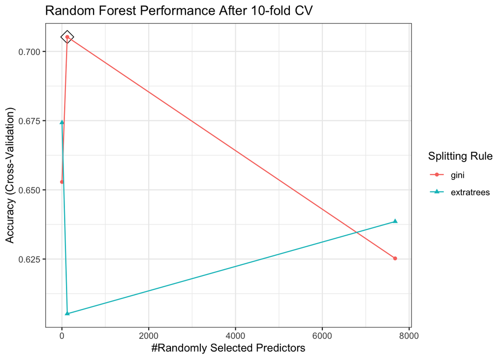

You’ll notice that by default with the 10-fold CV is that **it is doing automated hyperparameter tuning too!** Also, note the x-axis here. It is actually the $m_{try}$ hyperparameter, the number of randomly selected predictors $P$ at each split. So, you can **visualize the effect of** $m_{try}$ **on accuracy.**

##### **Question 4**: What combination of hyperparameters gives the highest accuracy in the **training model**? (Use plot above to answer.)

> Your answer here.

#### 3. Extract best model.

But what we’d really like to know is what the best model was:

Table 1. Results of the 10-fold CV Random Forest

|  | mtry | splitrule | min.node.size |
| --- | --- | --- | --- |
| 3 | 123 | gini | 1 |

#### 4. Fit the test data to the best tuned model from the 10-fold CV.

```r
rfCV <- train(Treatment ~.,
               data = train,
               method = "ranger",
               trControl = kFoldCtrl,
               tuneGrid = rfCV$bestTune)   # Add in the results of the CV and auto tuning


pred.test.rf <- predict(rfCV, test, type = "raw")  ## type is now 'raw'
# Store the confusion matrix
confMatCV <- confusionMatrix(pred.test.rf, test$Treatment)
```

#### 5. Compare the two confusion matrices.

Table 2. Comparing Accuracy - Random Forest

| Metric | Confusion Matrix 1 | Confusion Matrix 2 |
| --- | --- | --- |
| Accuracy | 0.5714286 | 0.5714286 |
| Kappa | 0.1428571 | 0.1428571 |
| AccuracyLower | 0.2886094 | 0.2886094 |
| AccuracyUpper | 0.8233889 | 0.8233889 |
| AccuracyNull | 0.5000000 | 0.5000000 |
| AccuracyPValue | 0.3952637 | 0.3952637 |
| McnemarPValue | 0.6830914 | 0.6830914 |

##### **Question 5**: Can you see an impact of the pre-processing (to remove lowly expressed genes)?

> Your answer here.

##### **Question 6**: Can you see an impact of the 10-fold cross-validation?

> Your answer here.

## Further Tuning: Searching

Usually, we only have a vague idea of the best hyperparameters and thus the best approach to narrow our search is to evaluate a wide range of values for each hyperparameter. We can allow packages like `caret` to automatically search for us (as above), but if the goal is to generate the most exhaustive search of hyperparameters - and in a way that is agnostic to human error - we need to do a **search**. Searches come in several flavors, but we will be executing a **grid** search vs. a **random** search for our study because both are quite simple to execute with the packages we already have.

### Grid Search

As the name suggests, grid searches take a matrix of values and will iteratively and linearly search through the grid until all combinations have been tested. This is also sometimes referred to as a ‘Cartesian grid’ search.

##### How many searches to do?

You will always be limited by time & computational resources. As much as I would like this to be exhaustive, for our purposes we will be keeping this smaller and more manageable since we are not running it on a computing cluster or in parallel.

##### A Note about Randomness

You may have already noticed that you get different results from your teammates. Why? By default, `caret` is setting a random seed for each split, and so you could have a different set of seeds than someone else (or even versus when you run it again). Wait, that’s not terrible helpful, is it?

It is and it isn’t. You might imagine times when you just want to be able to run a model, check the fit, and move on. Other times, like this time, we need something highly reproducible. `caret` will allow us to set our seeds so that we can force it to be more reproducible. Once we have some seeds to add, we update the `kFoldctrl` object.

**NOTE**: When you strike out on your own, you may get a ‘bad seeds’ error. This is often because you need to increase the size of your sample space.

#### 1. Set the search grid.

```r
searchGrid <- expand.grid(
  mtry = floor(ncol(train) * c(.05, .15, .25, .35, .45)),
  splitrule = c("gini", "extratrees"),
  min.node.size = c(1, 3, 5, 10)
)
```

##### **Question 7**: How many different combinations are we going to search with this grid?

> Your answer here.

#### 2. Run the RF, this time adding in the search grid.

Be patient. This may take a few minutes to run.

```r
rfTuned <- train(Treatment ~.,
               data = train,
               method = "ranger",
               trControl = kFoldCtrl,
               tuneGrid = searchGrid # Add in the search grid
)
```

##### Figure 2. Visualize the Grid Search Performance:

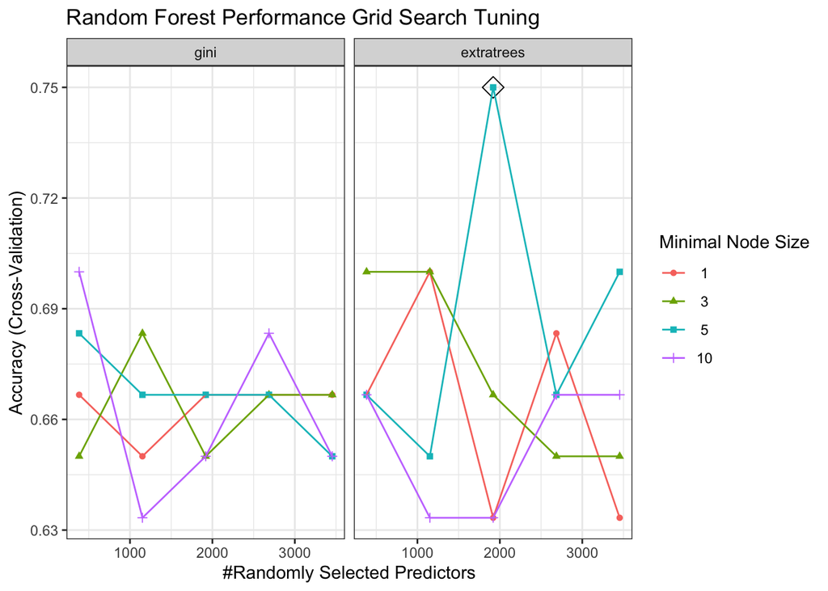

##### **Question 8**: What combination of hyperparameters gives the highest accuracy in the **training model**? (Use plot above to answer.) > Your answer here.

#### 3. Take a look at the hyperparameters of the best model:

```r
rfTuned$bestTune %>%
kable(
    format = "html",
    caption = "Table 3. Results of the Grid Search on Random Forest") %>%
    kable_styling(bootstrap_options = c("hover", full_width = F))
```

Table 3. Results of the Grid Search on Random Forest

|  | mtry | splitrule | min.node.size |
| --- | --- | --- | --- |
| 23 | 1919 | extratrees | 5 |

#### 4. Refit the best model’s hyperparameters to the test data set:

```r
rfTuned <- train(Treatment ~.,
               data = train,
               method = "ranger",
               trControl = kFoldCtrl,
               tuneGrid = rfTuned$bestTune)   # Add in the results of the CV and auto tuning
```

#### 5. Make the new predictions to assess accuracy:

```r
pred.test.rf <- predict(rfTuned, test, type = "raw")  ## type is now 'raw'
# Store the confusion matrix
confMatTuned <- confusionMatrix(pred.test.rf, test$Treatment)
```

#### 6. Compare the three confusion matrices:

```r
compareConfusion(confusionList = list(confMat, confMatCV, confMatTuned)) %>%
    kable(
    format = "html",
    caption = "Table 4. Comparing Accuracy - Random Forest") %>%
    kable_styling(bootstrap_options = c("hover", full_width = F))
```

Table 4. Comparing Accuracy - Random Forest

| Metric | Confusion Matrix 1 | Confusion Matrix 2 | Confusion Matrix 3 |
| --- | --- | --- | --- |
| Accuracy | 0.5714286 | 0.5714286 | 0.5000000 |
| Kappa | 0.1428571 | 0.1428571 | 0.0000000 |
| AccuracyLower | 0.2886094 | 0.2886094 | 0.2303605 |
| AccuracyUpper | 0.8233889 | 0.8233889 | 0.7696395 |
| AccuracyNull | 0.5000000 | 0.5000000 | 0.5000000 |
| AccuracyPValue | 0.3952637 | 0.3952637 | 0.6047363 |
| McnemarPValue | 0.6830914 | 0.6830914 | 0.4496918 |

##### **Question 9**: How well did hyperparameter tuning with the grid search perform?

> Your answer here.

**Note on methodology**: As I mentioned above, there is no parameter for the number of trees that we could tune in the search grid. Why not? It’s because we used the `train()` function from the `caret` package. `train()` is what is called a **wrapper function**, which means that we may be somewhat stuck using what’s available to us in the function. But what if we want to tune hyperparameters that are available through that wrapper function? We would need to switch our tactics. We could either write a **custom function or loop** to do it, or we could modify the function in `caret`. Wait, we can do that?! Yep!

##### **Question 10**: Use the `modelLookup` function to help you figure out what hyperparameters are available for the `rf` vs. `ranger` methods for performing random forest algorithm with `caret`. What are the key differences you observce in the hypers you can tune?

```r
# modelLookup("ranger")
# modelLookup("rf")
```

> Your answer here.

### Grid Search Using a Customized `caret` Method

#### 1. Write a customized `caret` method for random forest using the `ranger` method:

#### 2. Run the customized method:

**NOTE**: This takes about 12 min to run on 16gb of RAM.

```r
customRF <- makeCustomMethod(paramList = c("mtry",
                                           "num.trees",
                                           "min.node.size",
                                           "splitrule"),
                             methodName = "ranger")

searchGrid <- expand.grid(.mtry = floor(ncol(train) * c(.05, .15, .25)),
                        .num.trees = c(50, 200),
                        .min.node.size = c(1, 5, 10, 20),
                        .splitrule = "gini"
                        )

customTuned <- train(y = train$Treatment, x = train,
                method = customRF,
                metric = "Accuracy",
                tuneGrid = searchGrid,
                trControl = kFoldCtrl)
```

##### Figure 3. Visualize the Customized Grid Search Performance.

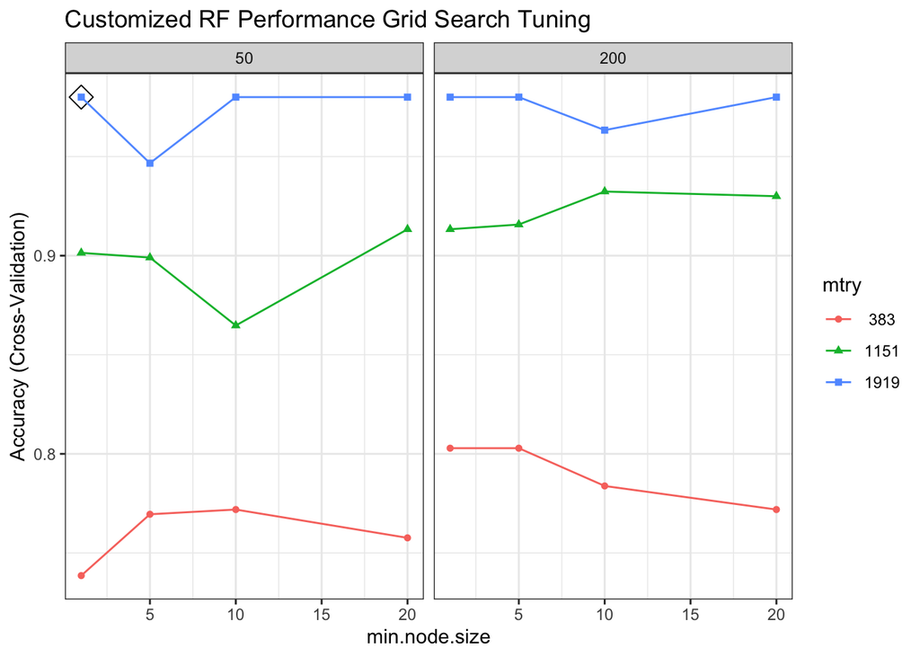

```r
ggplot(customTuned, highlight = TRUE) +
  ggtitle("Customized RF Performance Grid Search Tuning") +
  theme_bw()
```

##### **Question 11**: What combination of hyperparameters gives the highest accuracy in the **training model**? (Use plot above to answer.) How does it compare to previous results?

> Your answer here.

#### 3. Take a look at the hyperparameters of the best model.

```r
customTuned$bestTune %>%
kable(
    format = "html",
    caption = "Table 4. Results of the Customized Grid Search on Random Forest") %>%
    kable_styling(bootstrap_options = c("hover", full_width = F))
```

Table 4. Results of the Customized Grid Search on Random Forest

|  | mtry | num.trees | min.node.size | splitrule |
| --- | --- | --- | --- | --- |
| 17 | 1919 | 50 | 1 | gini |

#### 4. Refit the best model’s hyperparameters to the test data set.

```r
newTuned <- train(Treatment ~.,
               data = train,
               method = customRF,
               trControl = kFoldCtrl,
               tuneGrid = customTuned$bestTune)
```

#### 5. Make the new predictions to assess accuracy.

```r
pred.test.rf <- predict(newTuned, test, type = "raw")
# Store the confusion matrix
confMatTuned2 <- confusionMatrix(pred.test.rf, test$Treatment)
```

Table 4. Comparing Accuracy - Random Forest

| Metric | Confusion Matrix 1 | Confusion Matrix 2 | Confusion Matrix 3 | Confusion Matrix 4 |
| --- | --- | --- | --- | --- |
| Accuracy | 0.5714286 | 0.5714286 | 0.5000000 | 0.5714286 |
| Kappa | 0.1428571 | 0.1428571 | 0.0000000 | 0.1428571 |
| AccuracyLower | 0.2886094 | 0.2886094 | 0.2303605 | 0.2886094 |
| AccuracyUpper | 0.8233889 | 0.8233889 | 0.7696395 | 0.8233889 |
| AccuracyNull | 0.5000000 | 0.5000000 | 0.5000000 | 0.5000000 |
| AccuracyPValue | 0.3952637 | 0.3952637 | 0.6047363 | 0.3952637 |
| McnemarPValue | 0.6830914 | 0.6830914 | 0.4496918 | 0.6830914 |

##### **Question 12**: How well did hyperparameter tuning with the grid search perform?

> Your answer here.

### Random Search

Hopefully, you remember from lecture that a random search is where we randomly choose hyperparameters and, based on an initial set of random values, iteratively search until we get closer and closer to the best fit. Now, at this point we might also consider performing a random search in addition to the grid search; however, as we can see that we are generally STILL seriously under-performing, let’s table that idea and put our efforts somewhere we will hopefully see a bigger impact: **Nested Cross-Validation**.

## Nested Cross-Validation

As we have already discussed in lecture and Assignment 1, the norm in machine learning is to have a lot of of observations ($n$) than the number of features ($P$). Although it is tempting to think the same thing here, remember that the columns here are not features but rather samples! Thus,they are the individual observations or $n$.

Whenever $P >> N$ as here, our typical approaches for cross-validation must change. We have several options, but here we will employ a **nested cross-validation** approach. Other options would include a hold out or leave-one-out, although with some caveats.

**You will find that this method is not employed as much as it should be yet in gene expression analysis.** Why? Conceptually, this may be a bit hard to understand - and ML methods are already really different from what is done with the conventional methods like `DESeq2`. We will discuss more about **what** nested CV is in lecture, but for now here are the basics.

### The `nestedcv` package

Although we can also execute this with custom functions or loops, it’s usually going to be far more expedient to leverage a pre-existing package. Here, we will use the `nestedcv` package.

`nestedcv` partitions the dataset into outer and inner folds, with the default being 10-fold outer CV and 10-fold inner CV, also called **10 x 10 folds** CV. The inner-fold cross validation tunes the optimal hyperparameters for whatever model(s) are run. The model is then fitted on the whole inner-fold and tested against the left-out data from the outer-fold. This is repeated across all outer-folds. Then, the test predictions from the outer-folds are compared against the true results for the test outer-folds. The combined results give a measure of accuracy for the whole dataset as you are accustomed, e.g., either RMSE for regression or AUC for classification.

Lastly, a final round of cross-validation is performed on the whole dataset to determine hyperparameters to fit the final model to the whole data, which can be used for prediction with external data (which could be yet another test set you have withheld, for example, as we’ve been doing).

**Whew!**

Shall we try it?!?

#### 1. Set a search grid and train the model using the `nestedcv.train()` function.

Note that the setup looks a little reminiscent of our customized `caret` function. That’s because the authors of this package are doing something similar, although they have improved the computational speed. We could do that too - if we wanted to write a package. Otherwise, we can just let ours run and take a coffee break. :) **Important**: We are not able to use $m_{try}$ as large as we are used to because we’re doing inner- and outer-folds. We lowered $m_{try}$ here as a result. If you are doing this on different data and you get an error, that’s something to look into!

```r
searchGrid <- expand.grid(.mtry = floor(ncol(train) * c(0.01, 0.05, 0.10)),
                        .min.node.size = c(1, 5, 10),
                        .splitrule = "gini"
                        )

ncv <- nestcv.train(y = train$Treatment, x = train,
                    method = 'ranger',
                    tuneGrid = searchGrid,
                    savePredictions = "final")
```

```
## Fitting final model using CV on whole data
```

```
## Performing 10-fold outer CV, using 1 core
```

```
## Duration: 12.31723 mins
```

##### Figure 4. Visualize the Nested CV Performace on RF while also using a Grid Search of hyperparameters.

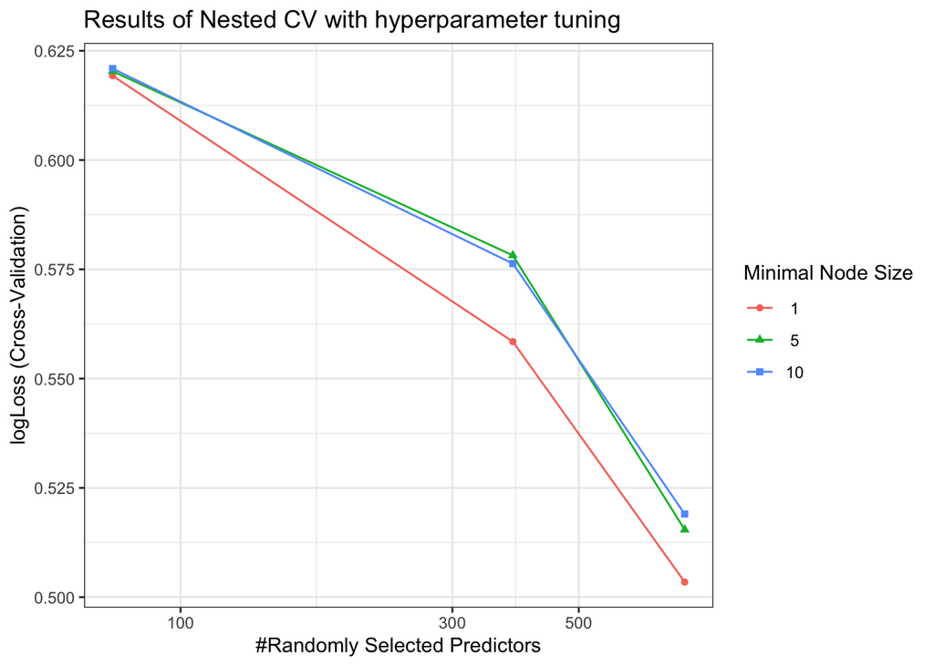

##### **Question 13**: Notice that the y-axis is now **log-Loss** and not **accuracy**. You may need to do some digging, but can you figure out why? Sources can be helpful if you’re not sure you’re on the right track! > Your answer here.

You’re going to see something really weird here…

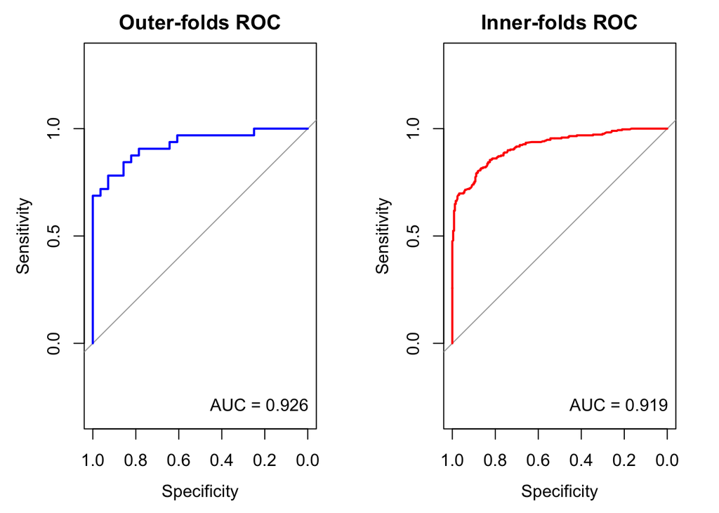

#### 5. Get that final accuracy by fitting to the test data.

Although, remember that with nested CV we have actually technically ‘seen’ the test data before.

```r
preds <- predict(ncv,
                 newdata = test)
confusionMatrix(preds, test$Treatment)
```

```
## Confusion Matrix and Statistics
##
##           Reference
## Prediction Control Cold
##    Control       6    0
##    Cold          1    7
##
##                Accuracy : 0.9286
##                  95% CI : (0.6613, 0.9982)
##     No Information Rate : 0.5
##     P-Value [Acc > NIR] : 0.0009155
##
##                   Kappa : 0.8571
##
##  Mcnemar's Test P-Value : 1.0000000
##
##             Sensitivity : 0.8571
##             Specificity : 1.0000
##          Pos Pred Value : 1.0000
##          Neg Pred Value : 0.8750
##              Prevalence : 0.5000
##          Detection Rate : 0.4286
##    Detection Prevalence : 0.4286
##       Balanced Accuracy : 0.9286
##
##        'Positive' Class : Control
##
```

> Your answer here.

#### 4. Grab the important features.

This is just for practice and to give you code to do it.

Table 5. Important Features from the Nested CV Grid Search on Random Forest

|  | MeanDecreaseGini |
| --- | --- |
| LOC100747964 | 5.818888 |
| LOC100750201 | 4.204819 |
| LOC100741821 | 3.716470 |
| LOC100741968 | 3.640853 |
| LOC100744633 | 3.278104 |
| LOC100749089 | 3.250547 |
| LOC100747104 | 3.156654 |
| LOC100745354 | 2.959198 |
| LOC100741270 | 2.954957 |
| LOC100749786 | 2.837945 |

#### 5. Compare our gene results to the ones out of `DESeq2`.

Remember, the ultimate goal was to see which ML method was getting us close to results from `DESeq2`, the respected, conventional method.

Let’s filter the nested CV randfom forest importance:

Now let’s compare that to what we got out of `DESeq2`. Note that I am setting a log-fold change filter to 1. In other words… any gene! Am I going to get any credible results?

Table 6. Overlapping Features identified from DESeq and Nested CV Random Forest

| baseMean | log2FoldChange | lfcSE | stat | pvalue | padj | geneID | MeanDecreaseGini |
| --- | --- | --- | --- | --- | --- | --- | --- |
| 18.48689 | 1.002242 | 0.5295007 | 1.892806 | 0.0583837 | 0.9999865 | LOC100740568 | 1.0005004 |
| 5169.76882 | 1.118413 | 0.9344836 | 1.196824 | 0.2313750 | 0.9999865 | LOC100747885 | 0.5190994 |

NOTE: I have had this list reshuffle on me. I believe the issue is with the `rf_filter()` function we’re using, and is something to consider for reproducibility!

#### 6. Find out what our top gene from nested CV random forest does.

##### **Question 15**: Should we have any confidence in these results? Why or why not?

> Your answer here.

# Takeaways & Next Steps

### Enter Phase 2 of this Project:

As we move forward with our benchmarking study, you have two choices. Choose your own adventure!

#### 1. Answer questions scattered throughout the Random Forest CV and Tuning Sections to ensure your understanding (you may copy these answers, without code, to your project document.)

#### **Path 1 - Potentially easier and more satisfying.**

Perform $k$-fold & nested CV, as well as hyperparameter tuning, on SVM a different VST (from the 30-minute experiment only)

If you decide to choose this adventure, you will use the vst data for the 30-min time point expression data only. You will also be given a list of genes identified as significantly expressed by DESeq2 at this time point for comparison.

Take this vst, and work through all the same steps as in this first-half of the project. **Make sure to look at the important features at the end and comment on whether you have any confidence in your results!**

#### **Path 2 - Potentially more challenging, and possibly just as dissatisfying as this one was.**

Ready to do go farther? Try performing $k$-fold & nested CV, as well as hyperparameter tuning, on SVM.

If you choose this adventure, you will have the option to work through this same vst OR the 30-minute VST and your challenge is to apply SVM, including tuning the hyperparameters of **kernel**, __gamma_, and **cost**. As I am currently working on a function that can help you get the important features out of a nested CV SVM, at this point you only need to engineer a best SVM model, discuss why you think it’s the best model, and what your next recommendations are.

# Final Comments

- Make sure to use the template I provide on GitHub for the project, rather than adding on to this document. It will just get too long!
- Make sure to answer the questions in your project document.

# References

Love, Michael I., Wolfgang Huber, and Simon Anders. 2014. “Moderated Estimation of Fold Change and Dispersion for RNA-Seq Data with DESeq2.” *Genome Biology* 15 (12): 550. https://doi.org/10.1186/s13059-014-0550-8.

R Core Team. 2019. *R: A Language and Environment for Statistical Computing*. Vienna, Austria: R Foundation for Statistical Computing. https://www.R-project.org.

Vabalas, Emma AND Poliakoff, Andrius AND Gowen. 2019. “Machine Learning Algorithm Validation with a Limited Sample Size.” *PLOS ONE* 14 (11): 1–20. https://doi.org/10.1371/journal.pone.0224365.

Verble, Kelton M., Ellen C. Keaveny, Sarthok Rasique Rahman, Matthew J. Jenny, Michael E. Dillon, and Jeffrey D. Lozier. 2024. “A Rapid Return to Normal: Temporal Gene Expression Patterns Following Cold Exposure in the Bumble Bee *Bombus Impatiens*.” *Journal of Experimental Biology* 227 (9): jeb247040. https://doi.org/10.1242/jeb.247040.